# Funciones algebraicas lineales

Vamos a empezar a programar funciones algebracias lineales en notebook

## Librerías

```python
import matplotlib.pyplot as plt
import numpy as np

#Configurando Latex
# Configuración de Matplotlib para usar LaTeX
plt.rcParams.update({
    "text.usetex": True,
    "font.family": "serif",
    "font.serif": ["Computer Modern Roman"],
    "text.latex.preamble": r"\usepackage{amsmath}"
})
```

## Funciones algebraicas

### Función lineal

Tiene la forma de $$f(x)=mx + b$$ donde $m$ y $b$ $\in R$.

$m$ puede ser calculada por: $$m=\frac{y_{2}-y_{1}}{x_{2}-x_{1}}$$

y $b$ es el punto de corte con el eje $y$. Su dominio es $Dom_{f} = (-\infty, \infty)$. Su imagen es $Im_{f} = (-\infty, \infty)$

El único termino que va a variar es $x$ entonces $m$ y $b$ van a ser constantes.  
Recordemos que el $Dominio$ de una función como esta, no está limitado, pero en programas computacionales es imposible ponerlo infinito, así que lo acotaremos a un espacio de trabajo.

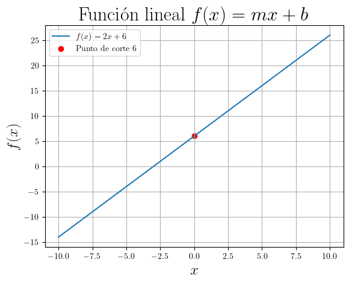

```python
#Definiendo variables y parámetros
N = 100
m = 2
b = 6

#Definiendo una función que calcula a f(x)
def f(x):
  return m*x+b

#Obteniendo valores de X e Y
#Aplicando la función a Y
x = np.linspace(-10,10, num=N)
y = f(x)
punto_corte=(0,f(0))

#Graficando
fig, ax = plt.subplots()
ax.plot(x,y,label=r'$f(x) = 2x + 6$')
ax.scatter(*punto_corte, color='red',label = f'Punto de corte {f(0)}')
# * se usa para desempaquetar
# nuestros valores de manera individual
# punto de corte ya que es una tupla
plt.title(r'Función lineal $f(x) =mx + b $',fontsize=23)
plt.xlabel(r'$x$',fontsize=18)
plt.ylabel(r'$f(x)$',fontsize=18)
plt.grid()
plt.legend()
plt.show()
```

Está gráfica tiene una pendiente positiva o creciente porque $m=2$, con un valor de $b=6$.

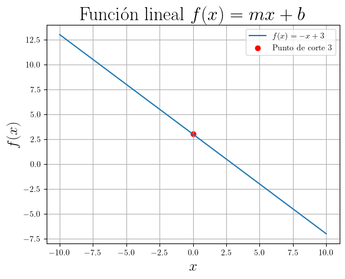

```python
#Definiendo variables y parámetros
N = 100
m = -1
b = 3

#Definiendo una función que calcula a f(x)
def f(x):
  return m*x+b

#Obteniendo valores de X e Y
#Aplicando la función a Y
x = np.linspace(-10,10, num=N)
y = f(x)
punto_corte = (0,f(0))

#Graficando
fig, ax = plt.subplots()
ax.plot(x,y,label=r'$f(x) = -x + 3$')
ax.scatter(*punto_corte, color='red',label = f'Punto de corte {f(0)}')
# * se usa para desempaquetar
# nuestros valores de manera individual
# punto de corte ya que es una tupla

plt.title(r'Función lineal $f(x) =mx + b $',fontsize=23)
plt.xlabel(r'$x$',fontsize=18)
plt.ylabel(r'$f(x)$',fontsize=18)
plt.grid()
plt.legend()
plt.show()
```

Esta función tiene un pendiente negativa o decreciente es decir $m=-1$ y con $b=3$.

### Caso particular con m=0

Cuando tenemos una función lineal con $m=0$ significa que tendremos una constante, es decir $b=constante$

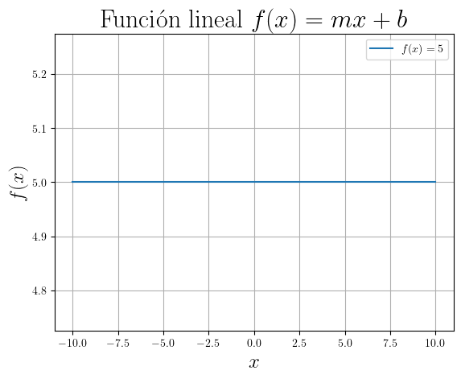

```python
#m=0
N = 100
m = 0
b = 5

#Definiendo una función que calcula a f(x)
def f(x):
  return m*x+b

#Obteniendo valores de X e Y
#Aplicando la función a Y
x = np.linspace(-10,10, num=N)
y = f(x)

#Graficando
fig, ax = plt.subplots()
ax.plot(x,y,label=r'$f(x) = 5$')

plt.title(r'Función lineal $f(x) = mx + b$',fontsize=23)
plt.xlabel(r'$x$',fontsize=18)
plt.ylabel(r'$f(x)$',fontsize=18)
plt.grid()
plt.legend()
plt.show()
```

Recordemos la función $f(x)=mx+b$ . En esta gráfica anterior de la función no tenemos pendiente osea $m=0$ entonces se vuelve un término constante por $b=5$

### Observaciones

Hay algo importante en este tipo de gráfica $f(x)=mx+b$.  
El término $b$ se le llama $bias$ y es el punto de corte de la recta donde $x=0$ adquiere el valor de $b$

### Funciones polinómicas

Tiene la forma de $$P(x)=a_{n}x^{n} + a_{n-1}x^{n-1}+...+a_{2}x^{2}+a_{1}x + a_{1}$$

a una función que tiene esta forma se le llama polinomio de grado $n$. A los elementos $a$ los llamaremos coeficientes donde $a \in R$.

**Por ejemplo:**

$$P(x)= 2x^{7} - x^{4} + 3x^{2} + 4$$

que es un polinomio de grado 7.

```
No artists with labels found to put in legend.  Note that artists whose label start with an underscore are ignored when legend() is called with no argument.
```

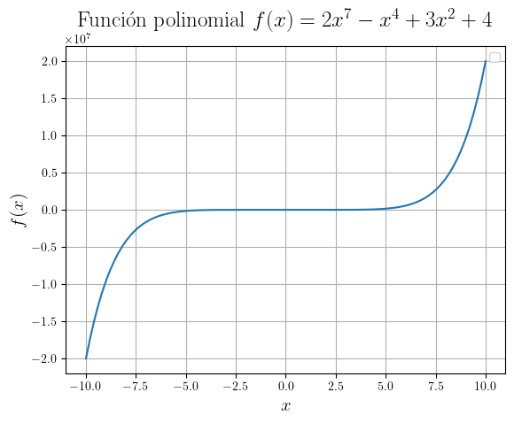

```python
#Funcion polinomica
def f(x):
  pol = (2*(x**7)-(x**4)+3*(x**2)+4)
  return pol

y = f(x)

plt.plot(x,y)
plt.grid()
plt.title(r'Función polinomial $f(x) = 2x^7-x^4+3x^2+4$',fontsize=18)
plt.xlabel(r'$x$',fontsize=15)
plt.ylabel(r'$f(x)$',fontsize=15)
plt.legend()
plt.show()
```

### Funciones potencia

Hay unas funciones que son un caso particular de las funciones polinómicas que son las funciones potencia, las cuales tienen la forma:

$$f(x)= x^{a}, a \in R$$

**Por ejemplo:**

$$f(x)= x^{2}$$

El dominio de $f(x)=x^{2}$ es $Dom_{f} = (-\infty, \infty)$. Su imagen es $Im_{f} = [0, \infty)$

```
No artists with labels found to put in legend.  Note that artists whose label start with an underscore are ignored when legend() is called with no argument.
```

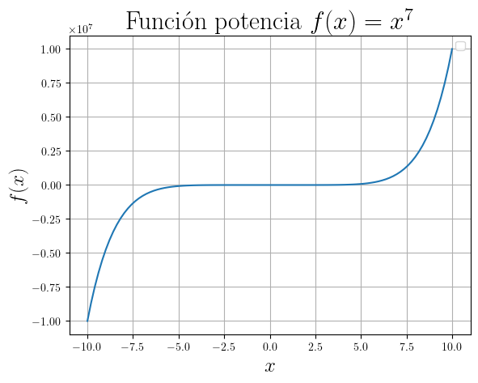

```python
#Funcion potencia
def f(x):
  return x**7

y = f(x)

plt.plot(x,y)
plt.grid()
plt.title(r'Función potencia $f(x) = x^7$',fontsize=23)
plt.xlabel(r'$x$',fontsize=18)
plt.ylabel(r'$f(x)$',fontsize=18)
plt.legend()
plt.show()
```

## Funciones trascendentes

Son funciones que no pueden ser expresadas con polinomios.

### Funciones trigonométricas

Son funciones que se relacionan con la geometría.

- Seno = $\sin(x) = \frac{cateto \; opuesto}{hipotenusa}$
- Coseno = $\cos(x) = \frac{cateto \; adyacente}{hipotenusa}$

```
No artists with labels found to put in legend.  Note that artists whose label start with an underscore are ignored when legend() is called with no argument.
```

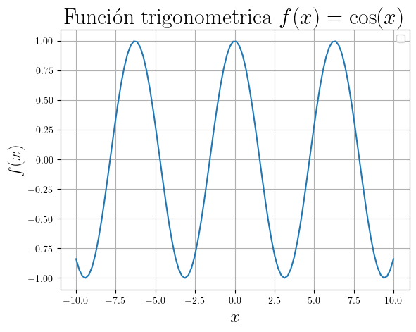

```python
#Función trigonometrica
def f(x):
  return np.cos(x)

y = f(x)

plt.plot(x,y)
plt.grid()
plt.title(r'Función trigonometrica $f(x) = \cos(x)$',fontsize=23)
plt.xlabel(r'$x$',fontsize=18)
plt.ylabel(r'$f(x)$',fontsize=18)
plt.legend()
plt.show()
```

### Función exponencial

Tienen la forma de $$f(x)=a^x$$ donde la base $a$ es una constante positiva. Un gran ejemplo de una función exponencial es usando la base como el número de euler:

$$f(x)=e^x$$

```
No artists with labels found to put in legend.  Note that artists whose label start with an underscore are ignored when legend() is called with no argument.
```

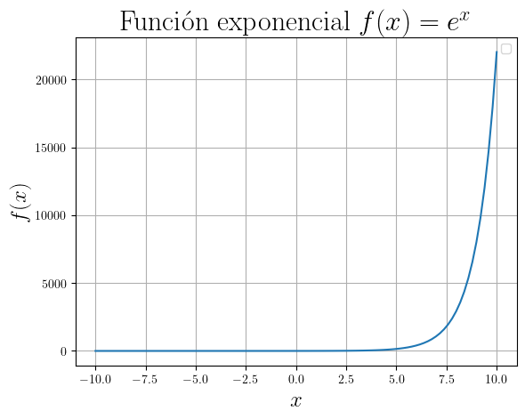

```python
#Función exponencial
def f(x):
  return np.exp(x)

y=f(x)

plt.plot(x,y)
plt.grid()
plt.title(r'Función exponencial $f(x) = e^x$',fontsize=23)
plt.xlabel(r'$x$',fontsize=18)
plt.ylabel(r'$f(x)$',fontsize=18)
plt.legend()
plt.show()
```

### Función logaritmo

El logaritmo está definido por la **relación**:

$$log_{b}(x) = n \Longleftrightarrow x=b^n$$

donde:

- $b$ es la base.
- $n$ es el exponente al que está elevado la base.
- $x$ es el resultado de elevar la base $b$ al exponente $n$

**Ejemplo:**

Teniendo b=2 y n=8, entonces:

$$2^8=256$$

Por lo que $x=256$. Calculando el logaritmo base 2 de $x$ es:

$$log_{2}(256) = 8$$

```
No artists with labels found to put in legend.  Note that artists whose label start with an underscore are ignored when legend() is called with no argument.
```

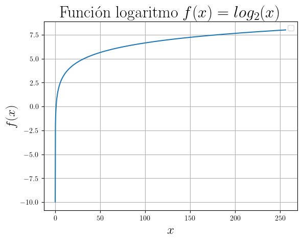

```python
#Función logaritmo
def f(x):
  return np.log2(x)

x = np.linspace(0.001,256, num=1000)

plt.plot(x,f(x))
plt.grid()
plt.title(r'Función logaritmo $f(x) = log_2(x)$',fontsize=23)
plt.xlabel(r'$x$',fontsize=18)
plt.ylabel(r'$f(x)$',fontsize=18)
plt.legend()
plt.show()
```

## Función seccionada

Son funciones que tienen diferentes valores definidos por un intervalo. Por ejemplo la función escalón de Heaviside:

$$H(x) = \begin{cases} 0, &\quad \text{para, } x < 0 \\ 1, &\quad\text{para. } x \ge 0 \\ \end{cases} $$

```
No artists with labels found to put in legend.  Note that artists whose label start with an underscore are ignored when legend() is called with no argument.
```

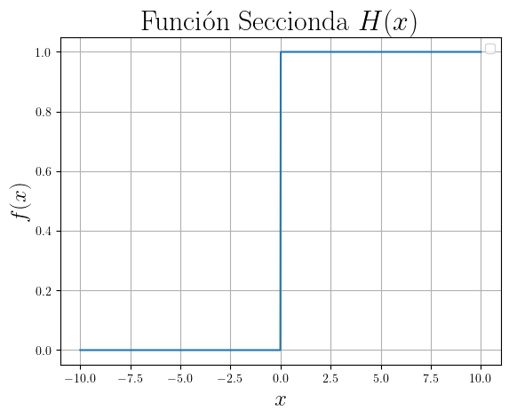

```python
def H(x):
  Y = np.zeros(len(x))
  for idx,x in enumerate(x):
    if x>=0:
      Y[idx]=1
  return Y


N=1000
x = np.linspace(-10,10, num=N)
y = H(x)

plt.plot(x,y)
plt.grid()
plt.title(r'Función Seccionda $H(x)$',fontsize=23)
plt.xlabel(r'$x$',fontsize=18)
plt.ylabel(r'$f(x)$',fontsize=18)
plt.legend()
plt.show()
```

## Extra

[figure not shown]

[figure not shown]